# R Notebook

# 4.4 For-loops

sum of 1+2+… +n is n(n+1)/2 What if we are not sure?

```r
compute_s_n <- function(n) {
  x <- 1:n
  sum(x)
}
```

how can we compute Sn for various values of n? We us for-loops here: performing same task over and over, changing value of n

```r
for(i in 1:5){
  print(i)
}
```

```
[1] 1
[1] 2
[1] 3
[1] 4
[1] 5
```

simple example of for-loop

```r
m <- 25
s_n <- vector(length = m) # create an empty vector
for(n in 1:m){
  s_n[n] <- compute_s_n(n)
}
```

in each iteration n=1, … we compute Sn and store it in the nth entry of s_n

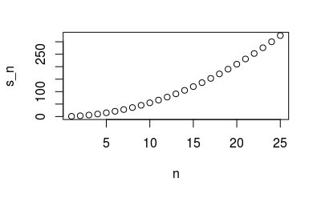

```r
n<- 1:m
plot(n, s_n)
```

quadratic; you’re right n(n+1)/2

|  | s_n | formula |
| --- | --- | --- |
| 1 | 1 | 1 |
| 2 | 3 | 3 |
| 3 | 6 | 6 |
| 4 | 10 | 10 |
| 5 | 15 | 15 |
| 6 | 21 | 21 |

we can also overlay two results by using function ‘lines’

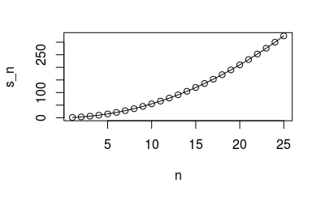

```r
plot(n, s_n)
lines(n, n*(n+1)/2)
```

# 4.5 Vectorization and functionals

we rarely use for-loops in R vectorization is preferred - results in shorter, clearer code

```r
x<- 1:10
sqrt(x)
```

```
 [1] 1.000000 1.414214 1.732051 2.000000 2.236068
 [6] 2.449490 2.645751 2.828427 3.000000 3.162278
```

```r
y <- 1:10
x*y
```

```
 [1]   1   4   9  16  25  36  49  64  81 100
```

not all functions work this way compute_s_n does not work element-wise

```r
n <- 1:25
compute_s_n(n)
```

```
numerical expression has 25 elements: only the first used
```

```
[1] 1
```

functionals; functions that help us apply the same function to each entry in a vector, matrix, data frame or list ‘sapply’ perform element-wise operations on any function

```r
x <- 1:10
sapply(x, sqrt)
```

```
 [1] 1.000000 1.414214 1.732051 2.000000 2.236068
 [6] 2.449490 2.645751 2.828427 3.000000 3.162278
```

each element of x is passed on to the function sqrt the result is a vector of the same length as the original x for-loops can be written as:

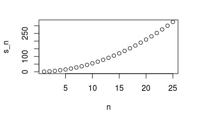

```r
n <- 1:25
s_n <- sapply(n, compute_s_n)
plot(n, s_n)
```

Other functionals are apply, lapply, tapply, mapply, vapply, and replicate

# 4.6 Exercises

Q1. Return?

```r
x <- c(1,2,-3,4)

if(all(x>0)){
  print("All Postives")
} else{
  print("Not all positives")
}
```

A1. Not all positives

Q2. Which of the following expressions is always FALSE when at least one entry of a logical vector x is TRUE?

A. all(x) B. any(x) C. any(!x) D. all(!x)

A2. D

Q3. The function nchar tells you how many characters long a character vector is. Write a line of code that assigns to the object new_names the state abbreviation when the state name is longer than 8 characters.

A3.

```r
new_names
```

```
 [1] "Alabama"  "Alaska"   "Arizona"  "Arkansas"
 [5] "CA"       "Colorado" "CT"       "Delaware"
 [9] "DC"       "Florida"  "Georgia"  "Hawaii"
[13] "Idaho"    "Illinois" "Indiana"  "Iowa"
[17] "Kansas"   "Kentucky" "LA"       "Maine"
[21] "Maryland" "MA"       "Michigan" "MN"
[25] "MS"       "Missouri" "Montana"  "Nebraska"
[29] "Nevada"   "NH"       "NJ"       "NM"
[33] "New York" "NC"       "ND"       "Ohio"
[37] "Oklahoma" "Oregon"   "PA"       "RI"
[41] "SC"       "SD"       "TN"       "Texas"
[45] "Utah"     "Vermont"  "Virginia" "WA"
[49] "WV"       "WI"       "Wyoming"
```

Q4. Create a function sum_n that for any given value, say n, computes the sum of the integers from 1 to n (inclusive). Use the function to determine the sum of integers from 1 to 5,000.

```r
sum_n <- function(n) {
  x <- 1:n
  sum(x)
}
```

```r
sum_n(5000)
```

```
[1] 12502500
```

Q5. Create a function altman_plot that takes two arguments, x and y, and plots the difference against the sum.

A5.

```r
altman_plot <- function(x, y) {
plot(x+y, abs(x-y))
}
```

Q6. After running the code below, what is the value of x?

```r
x <- 3
my_func <- function(y){
  x <- 5
  y+5
}
```

A6. 3

Q7. Write a function compute_s_n that for any given n computes the sum 1^2+ …. n^2. report the value of the sm when n=10

```r
compute_s_n <- function(n){
  x<- 1:n
  sum(x^2)
}
```

```r
compute_s_n(10)
```

```
[1] 385
```

Q8. Define an empty numerical vector s_n of size 25 using s_n <- vector(“numeric”, 25) and store in the results of s1, s2, …s25 using a for-loop

```r
s_n <- vector("numeric", 25)
for(i in 1:25){
  s_n[i] <- compute_s_n(i)
}
s_n
```

```
 [1]    1    5   14   30   55   91  140  204
 [9]  285  385  506  650  819 1015 1240 1496
[17] 1785 2109 2470 2870 3311 3795 4324 4900
[25] 5525
```

Q9. Repeat exercise 8, but this time use sapply.

```r
x<- 1:25
sapply(x, compute_s_n)
```

```
 [1]    1    5   14   30   55   91  140  204
 [9]  285  385  506  650  819 1015 1240 1496
[17] 1785 2109 2470 2870 3311 3795 4324 4900
[25] 5525
```

Q10. Repeat exercise 8, but this time use map_dbl.

```r
map_dbl(n,compute_s_n)
```

```
 [1]    1    5   14   30   55   91  140  204
 [9]  285  385  506  650  819 1015 1240 1496
[17] 1785 2109 2470 2870 3311 3795 4324 4900
[25] 5525
```

Q11. plot Sn versus n

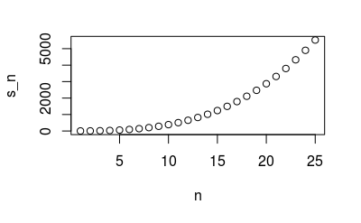

Q12. confirm that the formula for this sum is Sn=n(n+1)(2n+1)/6

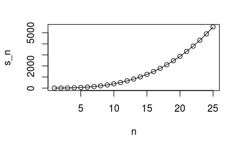

```r
plot(n, s_n)
lines(n, n*(n+1)*(2*n+1)/6)
```